# 不可挡的bookdown

Tue, Mar 14, 2017 未分类 bookdown, LaTeX, Markdown, R

最近，我打算把博客上关于R语言的帖子整理成一本书，希望弄得帅气一点，整齐一点，将来容易维护一点。涌进脑子的第一个念头是 $(\LaTeX)$ ，第二个念头是想吐。

是的，虽然我推崇 $(\LaTeX)$ ，觉得这个工具排出来的文档很漂亮，但自从弄完博士论文<sup>1</sup>{#fnref1.footnoteRef} 之后，除了帮别人备份一下博客<sup>2</sup>{#fnref2.footnoteRef} 、往论文里插几个公式和玩玩吉他谱<sup>3</sup>{#fnref3.footnoteRef}，我再也没碰过她。惰性开始代替折腾，我宁可点点鼠标写出一份不太美观的Word文档，也不想面对 $(\LaTeX)$ 那让人头疼的代码。大概我是真上了岁数罢。

对于 $(\LaTeX)$，我想自己的内心深处是怀有恐惧的。她的美丽让我着迷，她的复杂令人生畏。

所以，这次整理博客，我决定在Word里做。用了这么多年，对Word的秉性我算是略知一二，从一开始就用主控文档和子文档的方式管理，以防单个文档太大而死机；从标题到R代码，我预先都设置好了样式以及样式的快捷键，方便调整格式；每写几句话，就左手抽筋一样ctrl+s一下，以防万一。其间，发现帖子里有些R代码要修改调试，我就咬牙忍着在RStudio和Word之间频繁拷贝粘贴的煎熬。反正换回 $(\LaTeX)$ 也是一样想吐，既来之则安之，嫁鸡随鸡嫁狗随狗吧。

我天真地以为，这样就万无一失了。

有一天，我正在Word里改某篇帖子，改之前我留意了一下总页数是160多页。改了几个段落之后，我惊奇地发现，总页数成了220多页。再仔细找，发现有些代码区的文字无缘无故变成了乱码，一乱就新增几十页。进而测试发现，我正在好端端敲字，Word左下角的页数突然就刷刷地增加了，翻回去看，乱码已经被填进去了。试了好几次，都是这样。我甚至给文档权限设置为凭密码修订，仍然挡不住Word疯狂的脚步。

对着那自动呼呼上涨的页码，我想：认识十来年，想不到对你依然不了解。

$(\LaTeX)$ 的倩影再度闪现在我脑海。她虽然复杂，但至少源文件是纯文本，不会胡来，不像Word这么没有底线。

为什么就没有个像Word那么界面简单，像 $(\LaTeX)$ 那么源码单纯的两全其美方案呢？

“叮”的一声，脑子里冒出刚刚发布不久的bookdown(Xie 2016b)(Xie 2016a)。这是R语言的一个扩展包，专门用来写书，可以看作是R markdown的升级版。我的博客原文都是以markdown写成的，弄到bookdown里应当是顺理成章的事。只是大约因为上了岁数，我近几年对新工具越来越排斥，所以一直懒得尝试。这次被逼无奈，要不就试试吧。反正都是折腾，与其把精力花在让人心碎的Word里或让人心焦的 $(\LaTeX)$ 里，还不如花在崭新的bookdown里。就算是有缺点，还能比Word和 $(\LaTeX)$ 更不能忍么？

然后，刷！一晃十来天。春宵苦短日高起，从此君王不早朝。

这大半个月，我陶醉在bookdown的魅力里不可自拔。bookdown秉承拿来主义，把一大串工具链里的精华整合起来，让以前繁琐的步骤无比简化，怎一个爽快了得！她近乎完美地解决了我遇到的所有问题：纯文本操作，满足了我的控制欲；在导出完美的网页格式同时，还能导出为pdf和word文档，足够拿出来跟依赖Word的人交流；公式、脚注、交叉引用、目录、参考文献，功能齐全而不臃肿，格式标记简洁而优雅。我不再需要为Word的自以为是而抑郁，也不再需要为 $(\LaTeX)$ 的纷繁复杂而烦恼了。

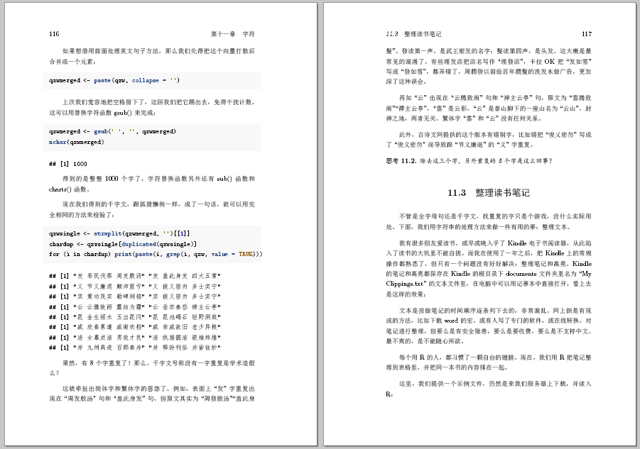

我用bookdown生成的书稿

一种亲切之美扑面而来，我感到无法抗拒无法阻挡。有了bookdown在手，写东西我还需要别的什么呢？想来想去，我不需要别的了。在Word和$(\LaTeX)$ 之间摇摆了十来年，到头来才发现bookdown才是真爱。

不过，bookdown绝非完美。如果不了解rmarkdown(Allaire et al. 2016)，没见过 $(\LaTeX)$ ，没听过pandoc，没用过knitr (Xie 2016c)(Xie 2015)(Xie 2014)，那么bookdown对新手来说，门槛仍然有点高。幸运的是，这几样工具我都用过，那么投入bookdown的怀抱就属于水到渠成了。即便如此，在使用初期仍然遇到了一些难以解决的问题，好在有bookdown的开发者益辉同学<sup>4</sup>{#fnref4.footnoteRef} 和其他同道中人热心地提供帮助，才能一路披荆斩棘，最后走上了幸福的康庄大道。

下面，我把我那些散落在各处的提问和解决方法汇总在这里。

1. 编译

起初我连bookdown的界面都没搞清楚，想编译却不知该点哪儿。益辉一直说build，build，我一直以为是菜单栏的build，后来才看到是在RStudio右上面板的build按钮。

bookdown是可以直接导出为word文档的。这么重要的功能，却隐藏得很深，在官方文档里都没有强调。导出方法是，在_output.yml里添加一行：

```
bookdown::word_document2: default
```

注意，`default`这个词是不能少的，不管它是不是默认。我也不知道为什么。

导出的word文档相当令人满意，参考文献的版式、图表的交叉引用都堪称完美。唯一不足之处，是公式的编号和交叉引用。bookdown的官方文档<sup>5</sup>{#fnref5.footnoteRef}给出的公式书写方案是，利用 $(\LaTeX)$ 的公式环境来编号和引用，这一点在生成pdf时没问题，但生成word时，会发现别说编号，连公式本身都消失了。这大概是因为pandoc未能将公式环境正确转换的缘故。解决办法是，不使用公式环境，而使用行内公式（即公式前后有一个美元符号），公式前面用圆括号里加公式标签就可以了。例如，输入：

```
(@eq-mc) $E = mc^2$

I like Eq. (@eq-mc) so much that I am falling love with her.
```

得到：

1. $E = mc^2$

I like Eq. (1) so much that I am falling love with her.

2. 中文支持

益辉专门为中文弄了个bookdown的中文示例文档<sup>6</sup>{#fnref6.footnoteRef}，编译需要的tex文件全都写好了，简直太体贴。我照猫画虎，却意外出现了编译错误，后来把preamble.tex的15到27行删掉，把index.Rmd里的 `colorlinks: yes` 改为 no，中文文档就华丽丽地编译出来了。

其间还出过其他的意外。我Windows的区域设置是German(Austria)，导致导出的文档里有乱码，只要把区域设置改为Chinese(PRC)就解决了大部分的乱码问题了。如果仍然有没解决的，那么将所有能设置编码的地方就全部设置成UTF-8，例如`readLines()`函数的encoding参数，`writeLines()`的useBytes参数等。

bookdown默认是按章节标题来生成网页文件名称，纯英文标题和纯中文标题都没问题，但对中英混合的标题，bookdown会只取其中的英文部分为html文件命名。如果每个章节标题里都有个R字母，那么生成的html文件就都叫R.html，编译时就会报错。解决办法是给heading添加{#ID}，让编译生成的html文件以此ID命名。解决是解决了，但又出现无编号章节标题{#ID} 和{-}共存问题。这就不知道怎么搜了，只好继续骚扰益辉，得到的答案是 `{#identifier .unnumbered}`。我就拿这个答案一搜，原来这一条明明白白写在pandoc的技术文档里，惭愧。

3. 参考文献

导出的网页格式文件里，参考文献的默认风格是apalike，方法是在index.Rmd的文件头用yaml声明`biblio-style`，得到的引用格式是“作者-年份”。我想改为数字编号引用，于是把上面改为plain或者ieeetr，但编译出来的网页文件仍然是apalike格式。益辉的答复是biblio-style仅对pdf生效；其他格式的文件需要用YAML或pandoc_args的csl选项——这个我懒得折腾了，按下不表。但即使是pdf文档，biblio-style设为plain或者ieeetr却编译失败。我忘了错误信息是什么了，好像大概是我的 $(\LaTeX)$ 出了点问题，后来改为unsrt风格就全好了。

如果要引用R的扩展包，knitr提供了函数`write_bib()`，用来生成指定扩展包的文献库，但是跟`citation()`函数得到的经常不一致。例如：

```r
knitr::write_bib(c(.packages(), 'lattice', 'ggplot2'), 'packages.bib')
```

得到的参考文献是扩展包在CRAN上的链接和版本信息，并且只能得到一个条目，这一点在bookdown的官方文档有说明。而`citation()`函数得到的是扩展包作者建议的参考文献条目，例如`citation('lattice')`就得到跟上面不同的返回结果。从尊重作者的角度来讲，我倾向于使用`citation()`函数，所以自己写了个函数来代替`write_bib()`：

```r
mf_bib <- function(pkg = c('base'), bibfile = 'packages.bib'){
  pkg <- unique(pkg[order(pkg)])
  for (i in pkg){
    # if (class(try(citation(i))) == 'try-error') install.packages(i)
    cti <- toBibtex(citation(i))
    entryloc <- grep(pattern = '^@', cti)
    cti[entryloc] <- gsub(',', paste('R-',i, ',', sep =''), cti[entryloc])
    symbol6loc <- grep('&', cti)
    for (j in symbol6loc) {
      cti[j] <- gsub(pattern = ' &', replacement = ' \\\\&', cti[j])
    }
    if (length(entryloc) > 1)  cti[entryloc] <- paste(substr(cti[entryloc], 1, nchar(cti[entryloc])-1), 1:length(entryloc), ',', sep ='')
    cat(cti, sep = '\n', file = bibfile, append = TRUE)
  }
}
```

运行这个函数，就能生成个bib格式的文献库文件。但这也有麻烦，就是有的扩展包作者建议的文献条目信息不齐全，还得我手动编辑；有的作者建议的条目太多，弄得参考文献列表很长，并且没必要。看来只能这两个函数搭配使用了。

解决了上面这些问题，基本上就走上了正轨。对我来说，bookdown是个素颜版的 $(\LaTeX)$ ，满足了99%的需求，而使用难度大概只有 $(\LaTeX)$ 的1%，性价比极高。这个“价”指的是弄懂她所花的精力和时间，bookdown本身当然是开源和免费的。想来是人上了岁数，不再看脸和身材，而是看重是否合得来吧。

更重要的一点是，bookdown还在不断完善和发展中，作者益辉同学年富力强，将来有的是机会把bookdown弄得更好（得盯住他不要为求完美而歪到 $(\LaTeX)$ 的老路上）。只盼早日把R + RStudio + bookdown + Dropbox + Github + Google LaTeX lab都整合到云端，到时候只需把输入数据一上传，打开个网页就写论文，别的什么都不用管，那么连剩下那$(\LaTeX)$%1的难度也都省了，天下太平。到了那个时候，使用bookdown就没有门槛，大家就会乐意用她来写诗集和小说了。

这时问题又来了：称手的兵刃有了，然而妖精在哪里？

注：本文是在R markdown环境下写成的。

参考文献：

Allaire, JJ, Joe Cheng, Yihui Xie, Jonathan McPherson, Winston Chang, Jeff Allen, Hadley Wickham, Aron Atkins, and Rob Hyndman. 2016. *Rmarkdown: Dynamic Documents for R*. https://CRAN.R-project.org/package=rmarkdown.

Xie, Yihui. 2014. “Knitr: A Comprehensive Tool for Reproducible Research in R.” In *Implementing Reproducible Computational Research*, edited by Victoria Stodden, Friedrich Leisch, and Roger D. Peng. Chapman; Hall/CRC. http://www.crcpress.com/product/isbn/9781466561595.

———. 2015. *Dynamic Documents with R and Knitr*. 2nd ed. Boca Raton, Florida: Chapman; Hall/CRC. http://yihui.name/knitr/.

———. 2016a. *Bookdown: Authoring Books and Technical Documents with R Markdown*. Boca Raton, Florida: Chapman; Hall/CRC. https://github.com/rstudio/bookdown.

———. 2016b. *Bookdown: Authoring Books and Technical Documents with R Markdown*. https://github.com/rstudio/bookdown.

———. 2016c. *Knitr: A General-Purpose Package for Dynamic Report Generation in R*. http://yihui.name/knitr/.

http://pzhao.org/archives/17095

http://pzhao.org/archives/16906

http://pzhao.org/archives/18230

https://yihui.name/cn/

https://bookdown.org/yihui/bookdown/

https://github.com/yihui/bookdown-chinese

[原文链接](http://dapengde.com/archives/19122)

[comments powered by Disqus](https://disqus.com)